# Introduction - Illustrative example

Theophanis Tsandilas and Géry Casiez

We detail our analysis for the illustrative example presented in the Introduction.

We use data from a hypothetical experiment that evaluates the time performance of three user interface techniques (*A*, *B*, and *C*) that help users complete image editing tasks of four different difficulty levels: *Level1*, *Level2*, *Level3*, and *Level4*.

### Preliminary

Let us first import all required libraries.

```r
library(lmerTest) # Lmer functions
library(ARTool) # ARTool library
library(effectsize) # To estimate effect sizes

# Additional libraries for plotting and reporting
library(kableExtra)
library(gridExtra)
library(ggplot2)
library(tidyverse)
```

### Reading the dataset

We read our dataset and fix the type of the factors:

```r
df <- read.csv("example-data-2.csv", sep=",", header=TRUE, strip.white=TRUE)

df$Participant <- factor(df$Participant)
df$Difficulty <- factor(df$Difficulty, ordered = TRUE) # We can consider it as ordinal
df$Technique <- factor(df$Technique)
```

We present our dataset with a table:

```r
kbl(df, booktabs = TRUE) %>% kable_styling(font_size=14) %>% kable_paper(position = "center") %>% scroll_box(height = "170px")
```

| Participant | Difficulty | Technique | Time |
| --- | --- | --- | --- |
| s01 | Level1 | Technique A | 0.0361042 |
| s01 | Level1 | Technique B | 0.0253609 |
| s01 | Level1 | Technique C | 0.1492974 |
| s01 | Level2 | Technique A | 0.1710746 |
| s01 | Level2 | Technique B | 0.2191633 |
| s01 | Level2 | Technique C | 0.2239972 |
| s01 | Level3 | Technique A | 0.8398766 |
| s01 | Level3 | Technique B | 0.3938725 |
| s01 | Level3 | Technique C | 0.3673203 |
| s01 | Level4 | Technique A | 0.6541780 |
| s01 | Level4 | Technique B | 0.6833174 |
| s01 | Level4 | Technique C | 1.0373519 |
| s02 | Level1 | Technique A | 0.0305443 |
| s02 | Level1 | Technique B | 0.0475272 |
| s02 | Level1 | Technique C | 0.1942220 |
| s02 | Level2 | Technique A | 0.1297270 |
| s02 | Level2 | Technique B | 0.5425377 |
| s02 | Level2 | Technique C | 0.1216511 |
| s02 | Level3 | Technique A | 0.4412080 |
| s02 | Level3 | Technique B | 0.6145893 |
| s02 | Level3 | Technique C | 2.5256672 |
| s02 | Level4 | Technique A | 0.4890620 |
| s02 | Level4 | Technique B | 0.9610943 |
| s02 | Level4 | Technique C | 0.8999087 |
| s03 | Level1 | Technique A | 0.0527914 |
| s03 | Level1 | Technique B | 0.4161652 |
| s03 | Level1 | Technique C | 0.0085943 |
| s03 | Level2 | Technique A | 0.3393474 |
| s03 | Level2 | Technique B | 0.2044622 |
| s03 | Level2 | Technique C | 0.2149051 |

[output cut: 210 more lines]

### Plotting the data

We then plot our data to observe the main trends.

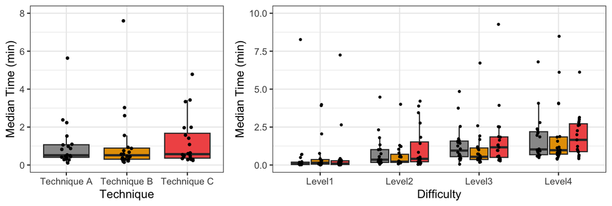

```r
cbPalette <- c("#999999", "#E69F00", "#F15854")

p1 <- (df %>%  group_by(Participant,Technique) %>%
summarise(Time = median(Time), .groups="drop") %>%
        ggplot(aes(x = Technique, y = Time, fill = Technique)) +
        geom_boxplot(outlier.shape = NA) +
        ylab("Median Time (min)") +
        ylim(0, 8) +
        geom_jitter(shape=20, position=position_jitter(0.1)) +
        theme_bw() + theme(legend.position = "none")) + scale_fill_manual(values=cbPalette)


p2 <- (df %>%  group_by(Participant,Difficulty,Technique) %>%
           summarise(Time = median(Time), .groups="drop") %>%
        ggplot(aes(x = Difficulty, y = Time, fill = Technique)) +
        geom_boxplot(outlier.shape = NA) +
        ylab("Median Time (min)") +
        ylim(0, 10) +
        geom_point(size = 0.7, position=position_jitterdodge(0.1)) +
        theme_bw() + theme(legend.position = "none")) +
        scale_fill_manual(values=cbPalette)

grid.arrange(p1, p2, nrow = 1, widths = c(1.5, 2.5))
```

### Statistical analysis

We conduct an analysis with five different methods: PAR, LOG, RNK, ART, and INT.

```r
# Implementation of the Inverse Normal Transform
int = function(x){
   qnorm((rank(x) - 0.5)/length(x))
}

mpar <- lmer(Time ~ Difficulty*Technique + (1|Participant), data=df) # Parametric - no transformation
mlog <- lmer(log(Time) ~ Difficulty*Technique + (1|Participant), data=df) # Parametric - Log-transformation
mart <- art(Time ~ Difficulty*Technique + (1|Participant), data=df) # ARTool
mrnk <- lmer(rank(Time) ~ Difficulty*Technique + (1|Participant), data=df) # Rank transformation
mint <- lmer(int(Time) ~ Difficulty*Technique + (1|Participant), data=df) # Inverse Transform transformation
```

### Main and interaction effects

We finally report the results of our analysis:

```r
# Function for printing the results for each method
printAnalysis <- function(num, method, model) {
  cat(num, ". Analysis using ", method, "\n\n", sep="")

  print(anova(model))
  print(eta_squared(model))
  print(cohens_f(model))
}

printAnalysis(1, "Logarithmic Transformation", mlog)
```

```
## 1. Analysis using Logarithmic Transformation
##
## Type III Analysis of Variance Table with Satterthwaite's method
##                       Sum Sq Mean Sq NumDF DenDF F value Pr(>F)
## Difficulty           206.596  68.865     3   209 97.4433 <2e-16 ***
## Technique              1.507   0.754     2   209  1.0663 0.3461
## Difficulty:Technique   6.728   1.121     6   209  1.5866 0.1524
## ---
## Signif. codes:  0 '***' 0.001 '**' 0.01 '*' 0.05 '.' 0.1 ' ' 1
## # Effect Size for ANOVA (Type III)
##
## Parameter            | Eta2 (partial) |       95% CI
## ----------------------------------------------------
## Difficulty           |           0.58 | [0.51, 1.00]
## Technique            |           0.01 | [0.00, 1.00]
## Difficulty:Technique |           0.04 | [0.00, 1.00]
##
## - One-sided CIs: upper bound fixed at [1.00].# Effect Size for ANOVA (Type III)
##
## Parameter            | Cohen's f (partial) |      95% CI
## --------------------------------------------------------
## Difficulty           |                1.18 | [1.03, Inf]
## Technique            |                0.10 | [0.00, Inf]
## Difficulty:Technique |                0.21 | [0.00, Inf]
##
## - One-sided CIs: upper bound fixed at [Inf].
```

```r
printAnalysis(2, "ART", mart)
```

```
## 2. Analysis using ART
##
## Analysis of Variance of Aligned Rank Transformed Data
##
## Table Type: Analysis of Deviance Table (Type III Wald F tests with Kenward-Roger df)
## Model: Mixed Effects (lmer)
## Response: art(Time)
##
##                              F Df Df.res     Pr(>F)
## 1 Difficulty           61.5993  3    209 < 2.22e-16 ***
## 2 Technique             7.4710  2    209 0.00073474 ***
## 3 Difficulty:Technique  2.7384  6    209 0.01393448   *
## ---
## Signif. codes:   0 '***' 0.001 '**' 0.01 '*' 0.05 '.' 0.1 ' ' 1
## # Effect Size for ANOVA (Type I)
##
## Parameter            | Eta2 (partial) |       95% CI
## ----------------------------------------------------
## Difficulty           |           0.47 | [0.39, 1.00]
## Technique            |           0.07 | [0.02, 1.00]
## Difficulty:Technique |           0.07 | [0.01, 1.00]
##
## - One-sided CIs: upper bound fixed at [1.00].# Effect Size for ANOVA (Type I)
##
## Parameter            | Cohen's f (partial) |      95% CI
## --------------------------------------------------------
## Difficulty           |                0.94 | [0.80, Inf]
## Technique            |                0.27 | [0.14, Inf]
## Difficulty:Technique |                0.28 | [0.09, Inf]
##
## - One-sided CIs: upper bound fixed at [Inf].
```

```r
printAnalysis(3, "Rank Transformation", mrnk)
```

```
## 3. Analysis using Rank Transformation
##
## Type III Analysis of Variance Table with Satterthwaite's method
##                      Sum Sq Mean Sq NumDF DenDF F value Pr(>F)
## Difficulty           408653  136218     3   209 98.9183 <2e-16 ***
## Technique              4785    2393     2   209  1.7376 0.1785
## Difficulty:Technique  13405    2234     6   209  1.6224 0.1423
## ---
## Signif. codes:  0 '***' 0.001 '**' 0.01 '*' 0.05 '.' 0.1 ' ' 1
## # Effect Size for ANOVA (Type III)
##
## Parameter            | Eta2 (partial) |       95% CI
## ----------------------------------------------------
## Difficulty           |           0.59 | [0.52, 1.00]
## Technique            |           0.02 | [0.00, 1.00]
## Difficulty:Technique |           0.04 | [0.00, 1.00]
##
## - One-sided CIs: upper bound fixed at [1.00].# Effect Size for ANOVA (Type III)
##
## Parameter            | Cohen's f (partial) |      95% CI
## --------------------------------------------------------
## Difficulty           |                1.19 | [1.04, Inf]
## Technique            |                0.13 | [0.00, Inf]
## Difficulty:Technique |                0.22 | [0.00, Inf]
##
## - One-sided CIs: upper bound fixed at [Inf].
```

```r
printAnalysis(4, "Inverse Normal Transformation", mint)
```

```
## 4. Analysis using Inverse Normal Transformation
##
## Type III Analysis of Variance Table with Satterthwaite's method
##                      Sum Sq Mean Sq NumDF DenDF F value Pr(>F)
## Difficulty           78.424 26.1412     3   209 90.3172 <2e-16 ***
## Technique             0.868  0.4339     2   209  1.4993 0.2257
## Difficulty:Technique  2.462  0.4103     6   209  1.4175 0.2092
## ---
## Signif. codes:  0 '***' 0.001 '**' 0.01 '*' 0.05 '.' 0.1 ' ' 1
## # Effect Size for ANOVA (Type III)
##
## Parameter            | Eta2 (partial) |       95% CI
## ----------------------------------------------------
## Difficulty           |           0.56 | [0.49, 1.00]
## Technique            |           0.01 | [0.00, 1.00]
## Difficulty:Technique |           0.04 | [0.00, 1.00]
##
## - One-sided CIs: upper bound fixed at [1.00].# Effect Size for ANOVA (Type III)
##
## Parameter            | Cohen's f (partial) |      95% CI
## --------------------------------------------------------
## Difficulty           |                1.14 | [0.99, Inf]
## Technique            |                0.12 | [0.00, Inf]
## Difficulty:Technique |                0.20 | [0.00, Inf]
##
## - One-sided CIs: upper bound fixed at [Inf].
```

```r
printAnalysis(5, "No Transformation", mpar)
```

```
## 5. Analysis using No Transformation
##
## Type III Analysis of Variance Table with Satterthwaite's method
##                      Sum Sq Mean Sq NumDF DenDF F value    Pr(>F)
## Difficulty           73.520 24.5067     3   209  8.6037 2.066e-05 ***
## Technique            12.950  6.4748     2   209  2.2731    0.1055
## Difficulty:Technique 17.421  2.9035     6   209  1.0194    0.4137
## ---
## Signif. codes:  0 '***' 0.001 '**' 0.01 '*' 0.05 '.' 0.1 ' ' 1
## # Effect Size for ANOVA (Type III)
##
## Parameter            | Eta2 (partial) |       95% CI
## ----------------------------------------------------
## Difficulty           |           0.11 | [0.04, 1.00]
## Technique            |           0.02 | [0.00, 1.00]
## Difficulty:Technique |           0.03 | [0.00, 1.00]
##
## - One-sided CIs: upper bound fixed at [1.00].# Effect Size for ANOVA (Type III)
##
## Parameter            | Cohen's f (partial) |      95% CI
## --------------------------------------------------------
## Difficulty           |                0.35 | [0.22, Inf]
## Technique            |                0.15 | [0.00, Inf]
## Difficulty:Technique |                0.17 | [0.00, Inf]
##
## - One-sided CIs: upper bound fixed at [Inf].
```

### Contrasts

Finally, we conduct an analysis of pairwise differences between the three techniques *A*, *B*, and *C*, using a Bonferroni correction. For ART, we use the `art.con` function.

```r
library("emmeans")

# Function for printing the results for each method
printContrasts <- function(num, method, expr, model) {
  cat(num, ". Contrasts using ", method, "\n\n", sep="")

  if(method == "ART") art.con(model, expr, adjust = "bonferroni")
  else contrast(emmeans(model, expr), method="pairwise", adjust = "bonferroni")
}

printContrasts(1, "Logarithmic Transformation", ~Technique, mlog)
```

```
## 1. Contrasts using Logarithmic Transformation
```

```
## NOTE: Results may be misleading due to involvement in interactions
```

```
##  contrast                  estimate    SE  df t.ratio p.value
##  Technique A - Technique B  -0.0408 0.133 209  -0.307  1.0000
##  Technique A - Technique C  -0.1848 0.133 209  -1.390  0.4980
##  Technique B - Technique C  -0.1439 0.133 209  -1.083  0.8404
##
## Results are averaged over the levels of: Difficulty
## Degrees-of-freedom method: kenward-roger
## Results are given on the log (not the response) scale.
## P value adjustment: bonferroni method for 3 tests
```

```r
printContrasts(2, "ART", ~Technique, mart)
```

```
## 2. Contrasts using ART
```

```
## NOTE: Results may be misleading due to involvement in interactions
```

```
##  contrast                  estimate  SE  df t.ratio p.value
##  Technique A - Technique B     6.99 7.2 209   0.970  0.9995
##  Technique A - Technique C   -19.85 7.2 209  -2.756  0.0191
##  Technique B - Technique C   -26.84 7.2 209  -3.725  0.0008
##
## Results are averaged over the levels of: Difficulty
## Degrees-of-freedom method: kenward-roger
## P value adjustment: bonferroni method for 3 tests
```

```r
printContrasts(3, "Rank Transformation", ~Technique, mrnk)
```

```
## 3. Contrasts using Rank Transformation
```

```
## NOTE: Results may be misleading due to involvement in interactions
```

```
##  contrast                  estimate   SE  df t.ratio p.value
##  Technique A - Technique B     1.96 5.87 209   0.334  1.0000
##  Technique A - Technique C    -8.34 5.87 209  -1.421  0.4704
##  Technique B - Technique C   -10.30 5.87 209  -1.755  0.2419
##
## Results are averaged over the levels of: Difficulty
## Note: contrasts are still on the rank scale
## Degrees-of-freedom method: kenward-roger
## P value adjustment: bonferroni method for 3 tests
```

```r
printContrasts(4, "Inverse Normal Transformation", ~Technique, mint)
```

```
## 4. Contrasts using Inverse Normal Transformation
```

```
## NOTE: Results may be misleading due to involvement in interactions
```

```
##  contrast                  estimate     SE  df t.ratio p.value
##  Technique A - Technique B  -0.0122 0.0851 209  -0.144  1.0000
##  Technique A - Technique C  -0.1332 0.0851 209  -1.566  0.3564
##  Technique B - Technique C  -0.1210 0.0851 209  -1.423  0.4689
##
## Results are averaged over the levels of: Difficulty
## Note: contrasts are still on the int scale
## Degrees-of-freedom method: kenward-roger
## P value adjustment: bonferroni method for 3 tests
```

```r
printContrasts(5, "No Transformation", ~Technique, mpar)
```

```
## 5. Contrasts using No Transformation
```

```
## NOTE: Results may be misleading due to involvement in interactions
```

```
##  contrast                  estimate    SE  df t.ratio p.value
##  Technique A - Technique B   -0.174 0.267 209  -0.653  1.0000
##  Technique A - Technique C   -0.556 0.267 209  -2.084  0.1150
##  Technique B - Technique C   -0.382 0.267 209  -1.431  0.4614
##
## Results are averaged over the levels of: Difficulty
## Degrees-of-freedom method: kenward-roger
## P value adjustment: bonferroni method for 3 tests
```

We observe again a significant divergence between the results of ART and the results of the other methods.